# Banana project, organic matter-microbiome

2023-12-01

# Data analysis octubre 2023

## Properties of soil

Method to obtain each parameter.

Five hundred grams of each soil sample were processed. The soils were air-dried at room temperature, sieved through a 2 mm sieve and homogenized. Oxidizable organic matter (%) was analyzed by oxidation with potassium dichromate in an acid medium and titrated with Mohr’s salt, using a procedure adapted from that described by Walkley et al. (1934). Assimilable phosphorus (mg/kg) was analyzed according to the colorimetric method of Olsen et al. (1954). Soil exchange cations (mEq/kg), calcium, magnesium, potassium and sodium, were extracted with neutral 1N ammonium acetate and determined by flame atomic absorption spectrophotometry (Bower et al., 1952). The pH in aqueous extract 1:5 (v:v) and in potassium chloride extract 1:5 (v:v) were determined by potentiometry with a combined glass electrode, with a procedure based on UNE-ISO 10390:2012 (2012). The electrical conductivity in extract 1:5 (mS/cm, µS/cm) by conductivity meter with the method based on UNE-EN 77308:2001 (2001).

The analyses of these parameters were carried out by the Laboratory Unit of the Canarian Institute of Agricultural Research (ICIA) Canary Island, Spain.

### Evolution of each parameter in the different times of the experiment

[figure not shown]

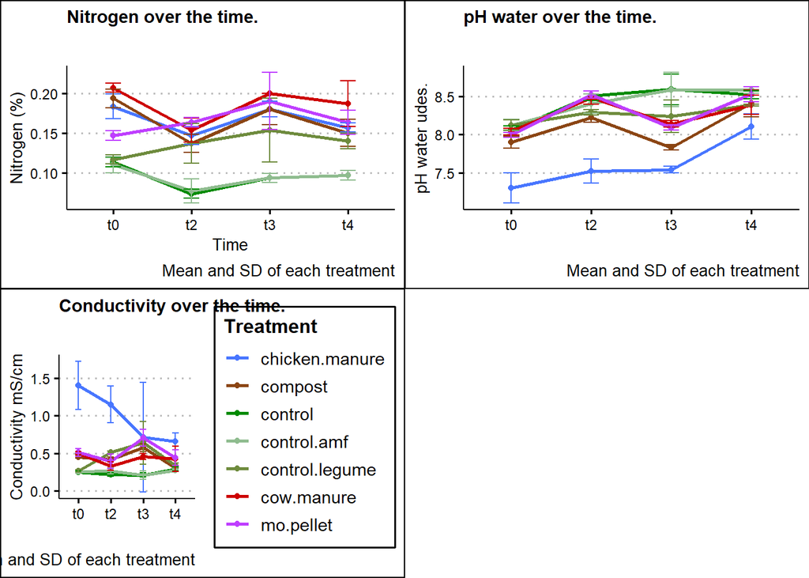

### Check the correlation between the variables to analyse the most interesting ones.

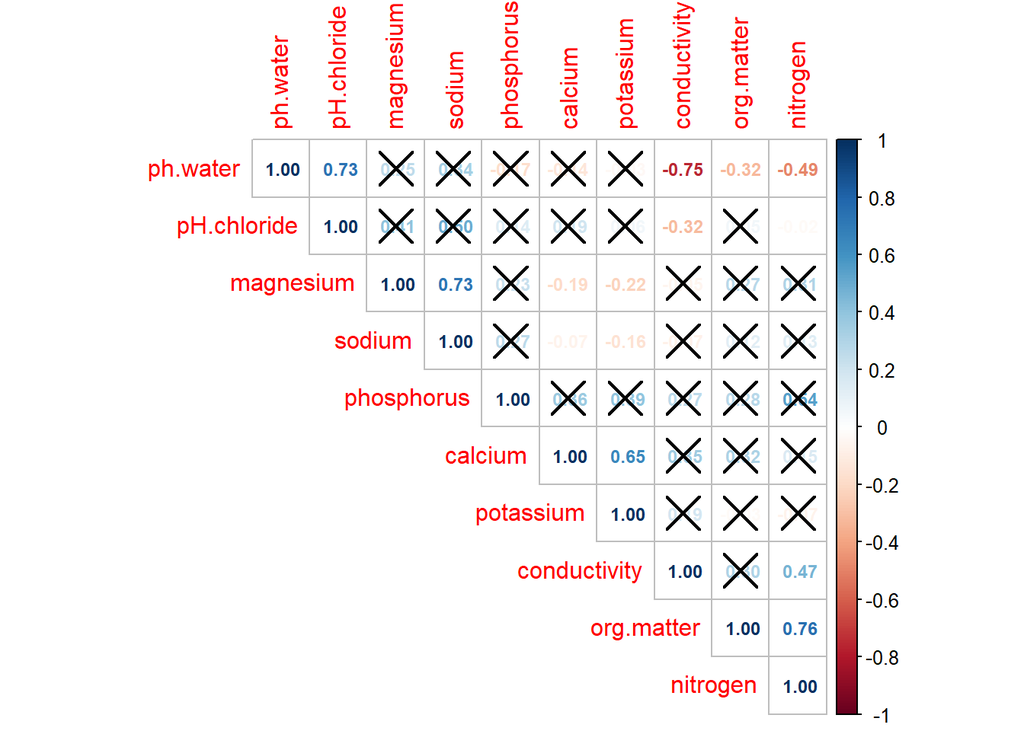

The most interesing variables seem to be pH.water, organic matter, conductivity and NPKCa values. The rest could be omitted.

## Differences between treatments at the start of the experiment (t0)

Para comprobar si hay diferencias significativas o no. 1.Dif. entre tratamientos y tiempos. 2.Dif. entre 1 tratamiento a lo largo del tiempo.

```
##
##  Shapiro-Wilk normality test
##
## data:  soilt0$org.matter
## W = 0.85814, p-value = 0.005885
```

```
## # A tibble: 7 x 4
##   treatment      variable   statistic      p
##   <chr>          <chr>          <dbl>  <dbl>
## 1 chicken.manure org.matter     0.865 0.0569
## 2 compost        org.matter     0.898 0.149
## 3 control        org.matter     0.879 0.0858
## 4 control.amf    org.matter     0.875 0.0748
## 5 control.legume org.matter     0.914 0.241
## 6 cow.manure     org.matter     0.931 0.392
## 7 mo.pellet      org.matter     0.922 0.306
```

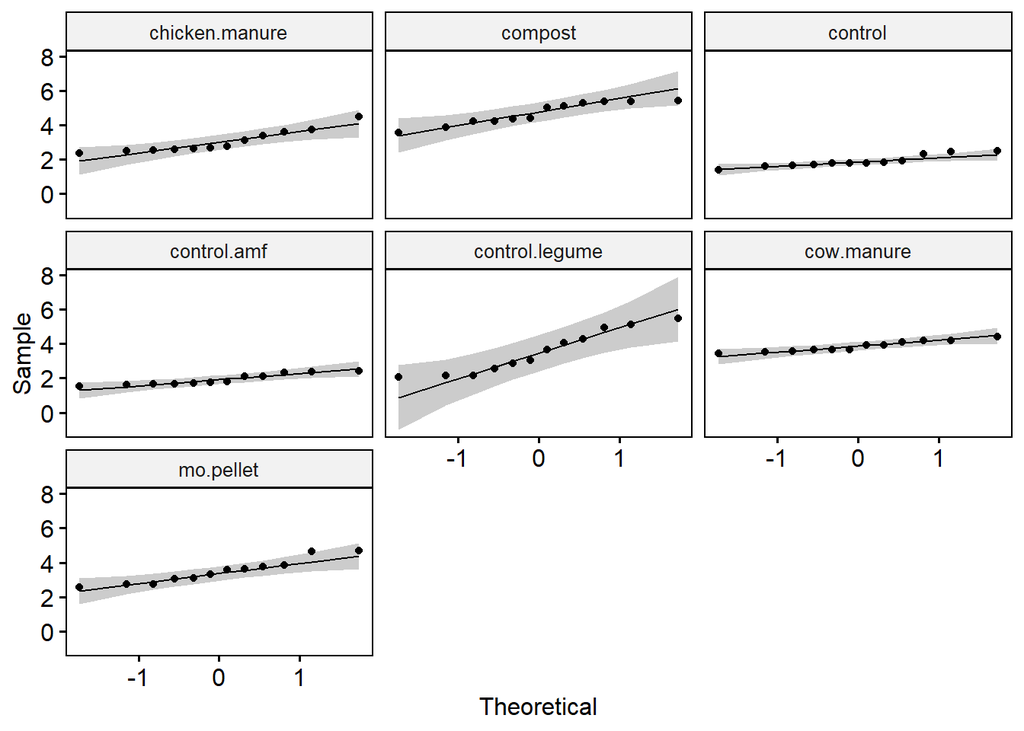

```
## Levene's Test for Homogeneity of Variance (center = median)
##       Df F value Pr(>F)
## group  6  0.5225 0.7822
##       14
```

```
##        treatment org.matter groups
## 1        compost   5.217000      a
## 2     cow.manure   4.061667      b
## 3 chicken.manure   3.565333      c
## 4      mo.pellet   2.687333      d
## 5        control   2.418400     de
## 6    control.amf   2.375667     de
## 7 control.legume   2.123333      e
```

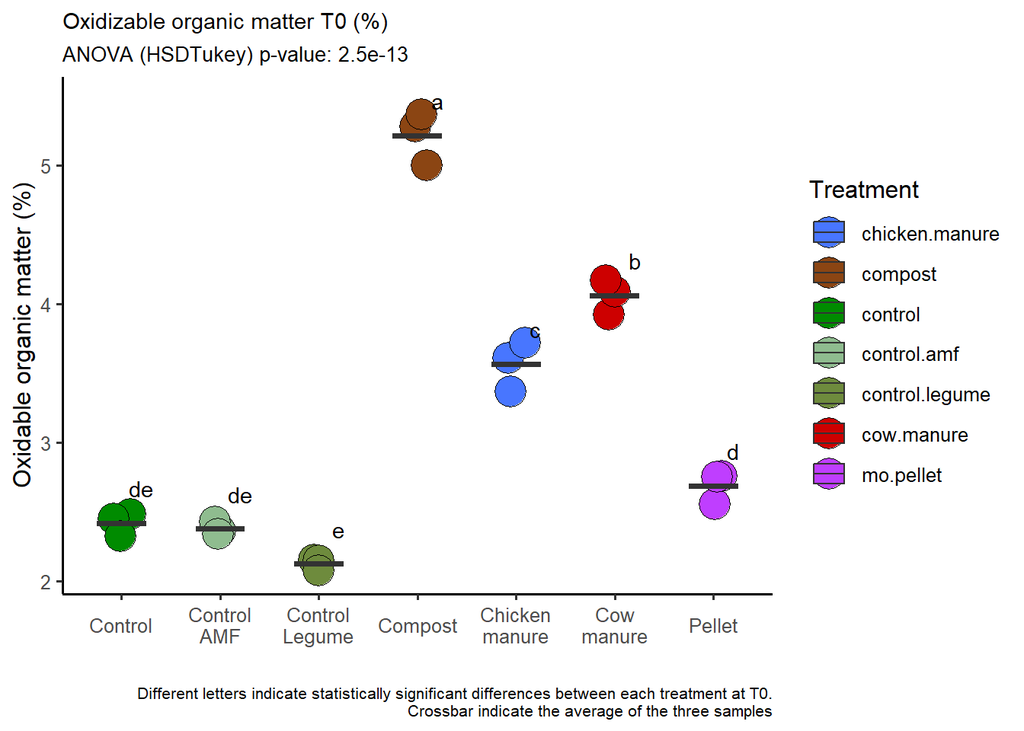

```
##
##  Shapiro-Wilk normality test
##
## data:  soilt0$phosphorus
## W = 0.88961, p-value = 0.02212
```

```
## # A tibble: 7 x 4
##   treatment      variable   statistic      p
##   <chr>          <chr>          <dbl>  <dbl>
## 1 chicken.manure phosphorus     1.00  0.969
## 2 compost        phosphorus     0.951 0.576
## 3 control        phosphorus     0.798 0.109
## 4 control.amf    phosphorus     0.867 0.287
## 5 control.legume phosphorus     0.998 0.915
## 6 cow.manure     phosphorus     0.788 0.0859
## 7 mo.pellet      phosphorus     0.850 0.241
```

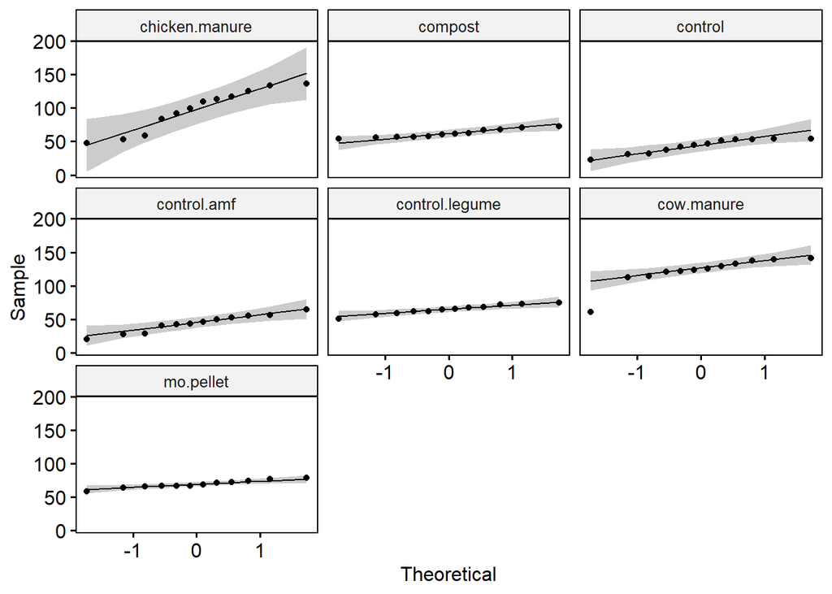

```
## Levene's Test for Homogeneity of Variance (center = median)
##       Df F value Pr(>F)
## group  6  0.8572 0.5485
##       14
```

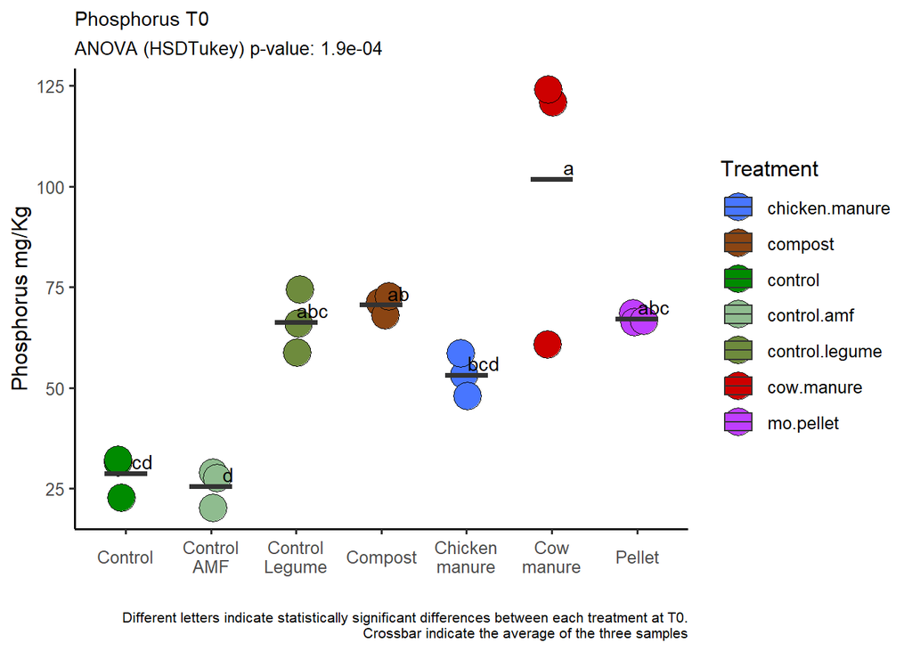

```
##
##  Shapiro-Wilk normality test
##
## data:  soilt0$ph.water
## W = 0.72161, p-value = 5.183e-05
```

```
## # A tibble: 7 x 4
##   treatment      variable statistic     p
##   <chr>          <chr>        <dbl> <dbl>
## 1 chicken.manure ph.water     0.983 0.747
## 2 compost        ph.water     0.995 0.862
## 3 control        ph.water     0.881 0.328
## 4 control.amf    ph.water     0.902 0.391
## 5 control.legume ph.water     0.812 0.144
## 6 cow.manure     ph.water     0.842 0.220
## 7 mo.pellet      ph.water     0.871 0.298
```

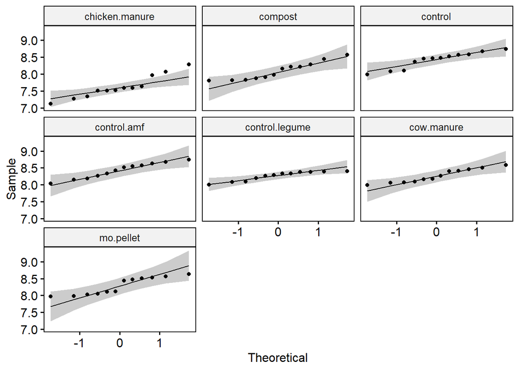

```
## Levene's Test for Homogeneity of Variance (center = median)
##       Df F value Pr(>F)
## group  6  1.0094 0.4576
##       14
```

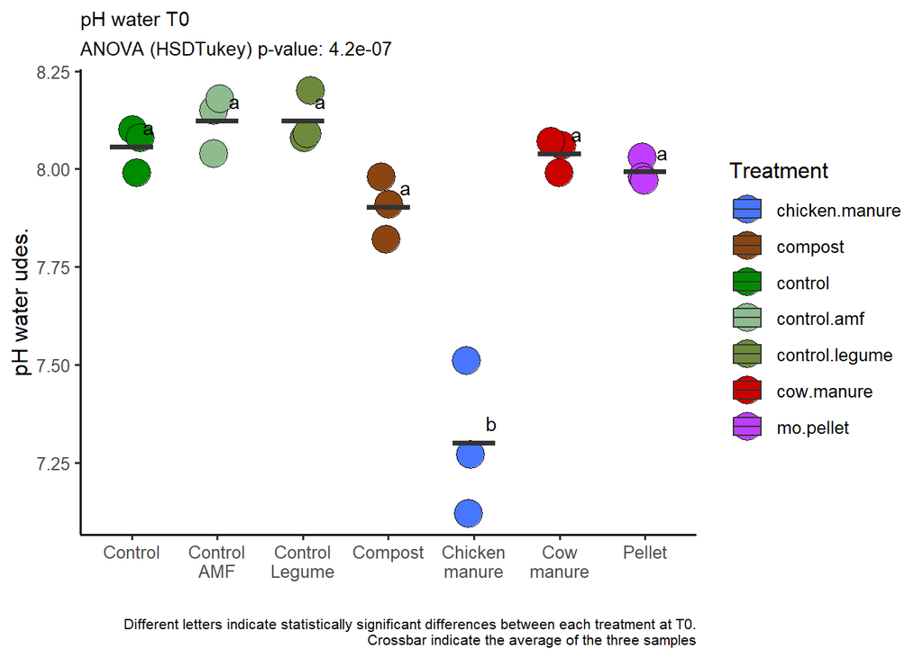

```
##
##  Shapiro-Wilk normality test
##
## data:  soilt0$conductivity
## W = 0.6867, p-value = 1.888e-05
```

```
## # A tibble: 7 x 4
##   treatment      variable     statistic       p
##   <chr>          <chr>            <dbl>   <dbl>
## 1 chicken.manure conductivity     0.971 0.919
## 2 compost        conductivity     0.984 0.995
## 3 control        conductivity     0.965 0.853
## 4 control.amf    conductivity     0.915 0.244
## 5 control.legume conductivity     0.796 0.00843
## 6 cow.manure     conductivity     0.972 0.932
## 7 mo.pellet      conductivity     0.956 0.731
```

```
## # A tibble: 7 x 4
##   treatment      variable          statistic      p
##   <chr>          <chr>                 <dbl>  <dbl>
## 1 chicken.manure sqrt_conductivity     0.934 0.421
## 2 compost        sqrt_conductivity     0.985 0.997
## 3 control        sqrt_conductivity     0.970 0.912
## 4 control.amf    sqrt_conductivity     0.895 0.135
## 5 control.legume sqrt_conductivity     0.866 0.0581
## 6 cow.manure     sqrt_conductivity     0.973 0.941
## 7 mo.pellet      sqrt_conductivity     0.969 0.904
```

```
## # A tibble: 7 x 4
##   treatment      variable     statistic     p
##   <chr>          <chr>            <dbl> <dbl>
## 1 chicken.manure conductivity     1.00  0.966
## 2 compost        conductivity     1     1.00
## 3 control        conductivity     0.964 0.637
## 4 control.amf    conductivity     0.75  0
## 5 control.legume conductivity     0.964 0.637
## 6 cow.manure     conductivity     1     1.00
## 7 mo.pellet      conductivity     0.893 0.363
```

```
##
##  Shapiro-Wilk normality test
##
## data:  soilt0$sqrt_conductivity
## W = 0.77704, p-value = 0.0002985
```

```
## # A tibble: 7 x 4
##   treatment      variable          statistic     p
##   <chr>          <chr>                 <dbl> <dbl>
## 1 chicken.manure sqrt_conductivity     0.997 0.902
## 2 compost        sqrt_conductivity     1.00  0.988
## 3 control        sqrt_conductivity     0.961 0.623
## 4 control.amf    sqrt_conductivity     0.75  0
## 5 control.legume sqrt_conductivity     0.967 0.650
## 6 cow.manure     sqrt_conductivity     1.00  0.989
## 7 mo.pellet      sqrt_conductivity     0.888 0.348
```

```
## Levene's Test for Homogeneity of Variance (center = median)
##       Df F value  Pr(>F)
## group  6  2.3351 0.08965 .
##       14
## ---
## Signif. codes:  0 '***' 0.001 '**' 0.01 '*' 0.05 '.' 0.1 ' ' 1
```

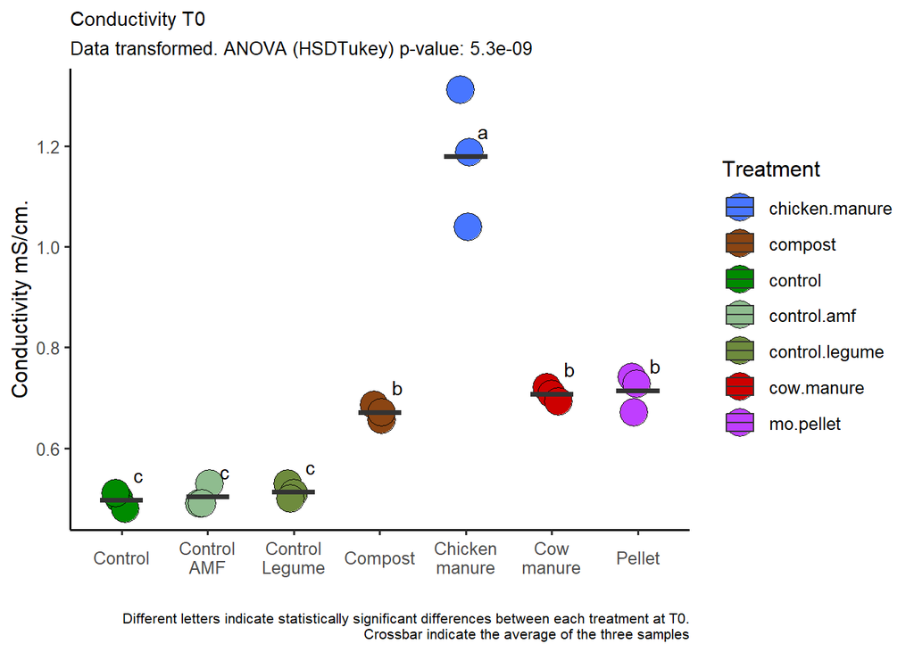

```
##
##  Shapiro-Wilk normality test
##
## data:  soilt0$calcium
## W = 0.9265, p-value = 0.1171
```

```
## Levene's Test for Homogeneity of Variance (center = median)
##       Df F value Pr(>F)
## group  6  0.6553 0.6862
##       14
```

```
##        treatment  calcium groups
## 1 chicken.manure 195.3333      a
## 2        compost 176.3333     ab
## 3     cow.manure 168.6667      b
## 4 control.legume 140.0000      c
## 5        control 136.6667      c
## 6    control.amf 136.3333      c
## 7      mo.pellet 135.3333      c
```

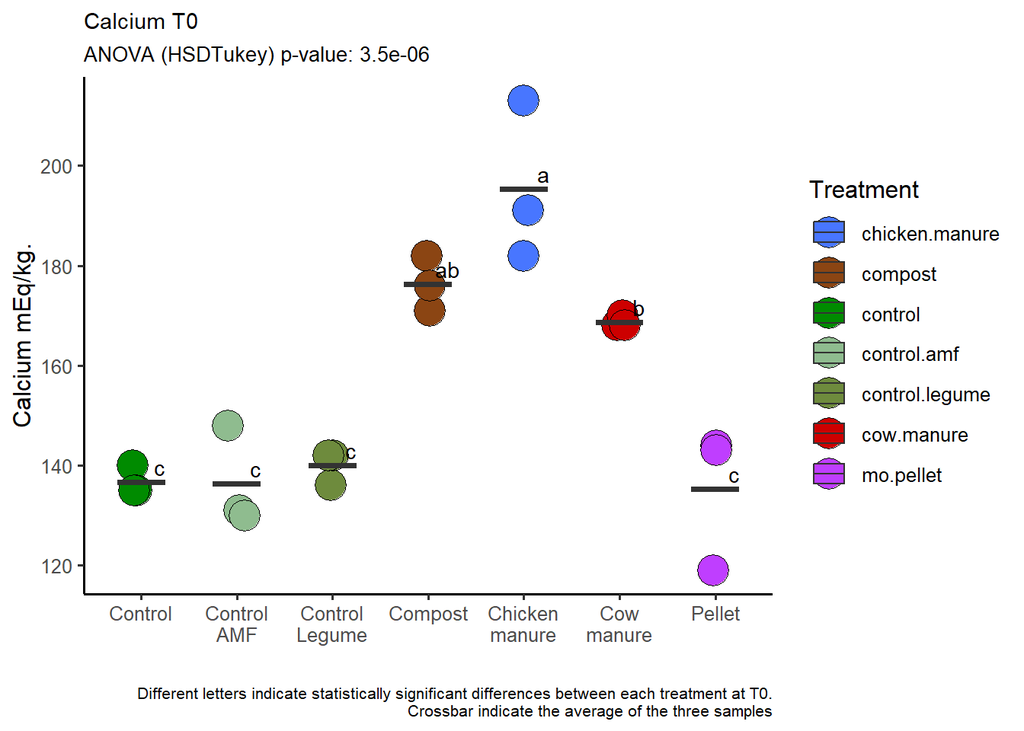

```
##
##  Shapiro-Wilk normality test
##
## data:  soilt0$sodium
## W = 0.94976, p-value = 0.3371
```

```
## Levene's Test for Homogeneity of Variance (center = median)
##       Df F value Pr(>F)
## group  6  0.2524 0.9502
##       14
```

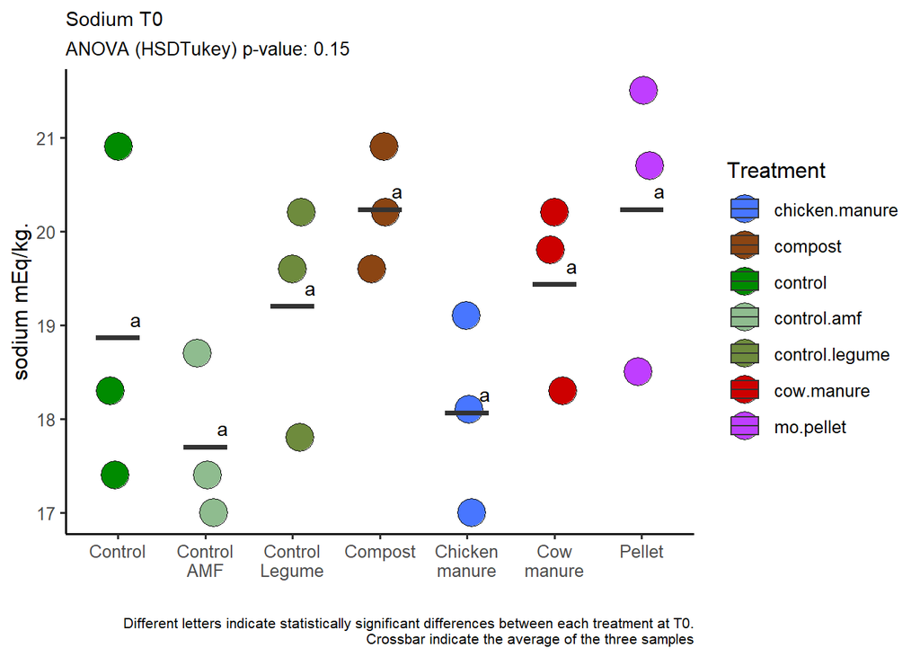

```
##
##  Shapiro-Wilk normality test
##
## data:  soilt0$potassium
## W = 0.92702, p-value = 0.12
```

```
## Levene's Test for Homogeneity of Variance (center = median)
##       Df F value Pr(>F)
## group  6  0.3255 0.9126
##       14
```

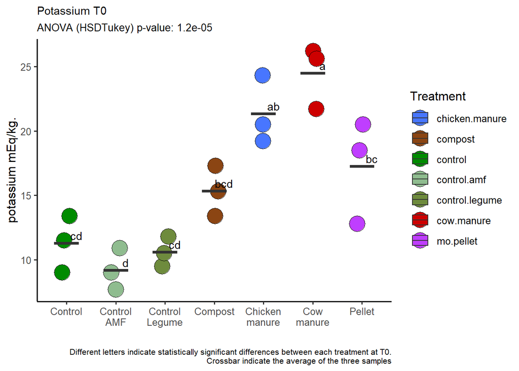

```
##
##  Shapiro-Wilk normality test
##
## data:  soilt0$nitrogen
## W = 0.86627, p-value = 0.008208
```

```
## # A tibble: 7 x 4
##   treatment      variable statistic      p
##   <chr>          <chr>        <dbl>  <dbl>
## 1 chicken.manure nitrogen     0.960 0.779
## 2 compost        nitrogen     0.894 0.133
## 3 control        nitrogen     0.948 0.615
## 4 control.amf    nitrogen     0.924 0.322
## 5 control.legume nitrogen     0.910 0.216
## 6 cow.manure     nitrogen     0.896 0.139
## 7 mo.pellet      nitrogen     0.841 0.0282
```

```
##
##  Shapiro-Wilk normality test
##
## data:  soilt0$log_nitrogen
## W = 0.8745, p-value = 0.01157
```

```
## # A tibble: 7 x 4
##   treatment      variable     statistic      p
##   <chr>          <chr>            <dbl>  <dbl>
## 1 chicken.manure log_nitrogen     0.959 0.764
## 2 compost        log_nitrogen     0.897 0.147
## 3 control        log_nitrogen     0.931 0.396
## 4 control.amf    log_nitrogen     0.874 0.0739
## 5 control.legume log_nitrogen     0.926 0.336
## 6 cow.manure     log_nitrogen     0.881 0.0903
## 7 mo.pellet      log_nitrogen     0.873 0.0705
```

```
## Levene's Test for Homogeneity of Variance (center = median)
##       Df F value Pr(>F)
## group  6   0.335 0.9071
##       14
```

```
##        treatment log_nitrogen
## 1 chicken.manure    -1.698731
## 2        compost    -1.644558
## 3        control    -2.178271
## 4    control.amf    -2.210041
## 5 control.legume    -2.149267
## 6     cow.manure    -1.576911
## 7      mo.pellet    -1.920118
```

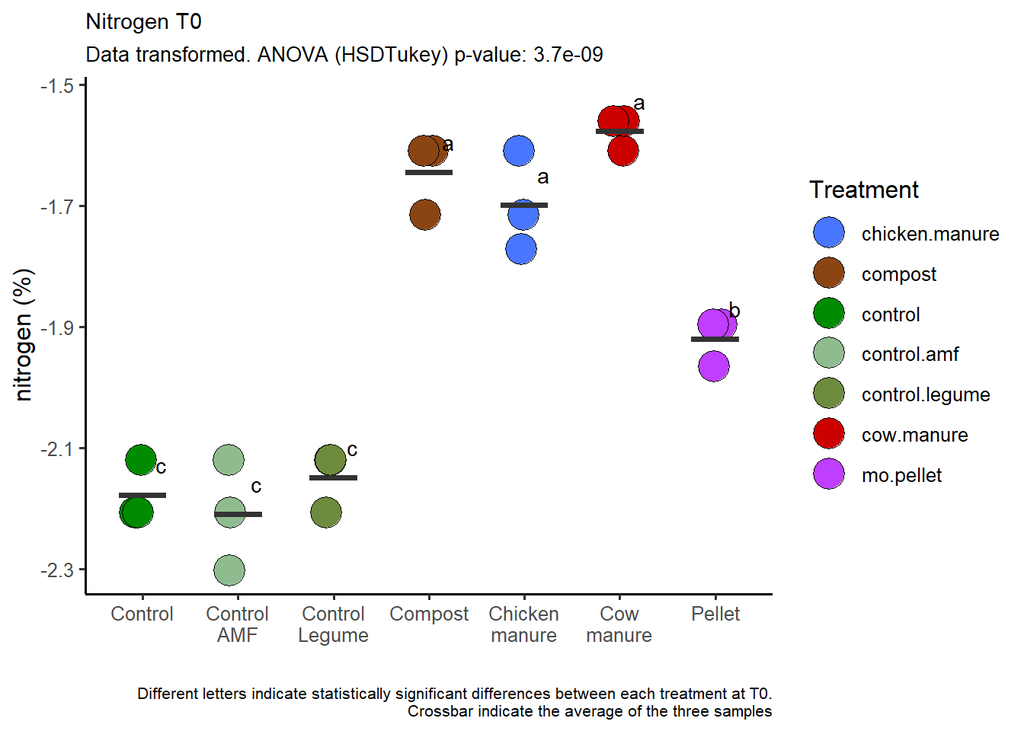

### Differences between treatments at the end of the experiment (t4)

```r
soilt4 <- subset(soil_prop, soil_prop$time== "t4")

shapiro.test(soilt4$org.matter) #normal data
```

```
##
##  Shapiro-Wilk normality test
##
## data:  soilt4$org.matter
## W = 0.92564, p-value = 0.1126
```

```r
leveneTest(org.matter~ treatment, data=soilt4) #equal variances
```

```
## Levene's Test for Homogeneity of Variance (center = median)
##       Df F value Pr(>F)
## group  6  0.8248 0.5694
##       14
```

[figure not shown]

```r
anova_orgmattert4 <- aov(org.matter ~ treatment, data=soilt4) #sig. different
anova_orgmattert4<- summary(aov(org.matter ~ treatment, data=soilt4))
pvalue_anova_orgmattert4<- anova_orgmattert4[[1]][["Pr(>F)"]][1]

tukey_orgmattert4 <- HSD.test(aov(org.matter ~ treatment, data=soilt4), "treatment", alpha = 0.05)$groups %>% rownames_to_column(var= "treatment")
avgmt4 <- aggregate(org.matter ~ treatment, data=soilt4, FUN= mean)
plot_orgmatter_t4 <- soilt4 %>% ggplot(aes(x= factor(treatment, level= treat.order), y= org.matter, fill=treatment))+
  geom_point(size= 7, pch= 22, col= "black", aes(fill= treatment), position= position_jitter(width=0.1, height=0))+
  scale_color_manual(values= treat.colors)+
  scale_fill_manual(values= treat.colors)+
  ylab("Oxidable organic matter (%)")+
  xlab("")+
  scale_x_discrete(labels= treat.labels)+
  theme_classic2()+
  guides(fill=guide_legend(title="Treatment"))+
  stat_summary(fun=mean, aes(x= treatment, y = org.matter),
               geom= "crossbar", width=0.6, colour= "black", data=avgmt4)+
  geom_text(data=tukey_orgmattert4, aes(x=treatment, y = org.matter, label= groups), color="black", nudge_x= 0.2, nudge_y= 0.2)+
  labs(title = "", subtitle = "", caption = "Different letters indicate statistically significant differences between each treatment at T4.\nCrossbar indicate the average of the three samples", size = 10 )+
  ggtitle("Oxidizable organic matter T4", subtitle= paste("Data transformed. ANOVA (HSDTukey) p-value: ", format(pvalue_anova_orgmattert4, scientific= TRUE, digits=2 ), sep= ""))+
  theme(
    plot.title = element_text(size = 11),
    plot.subtitle = element_text(size = 10),
    plot.caption = element_text(size = 8))
plot_orgmatter_t4
```

```
##
##  Shapiro-Wilk normality test
##
## data:  soilt4$phosphorus
## W = 0.82167, p-value = 0.001435
```

```
## # A tibble: 7 x 4
##   treatment      variable   statistic     p
##   <chr>          <chr>          <dbl> <dbl>
## 1 chicken.manure phosphorus     0.993 0.843
## 2 compost        phosphorus     0.921 0.455
## 3 control        phosphorus     0.987 0.780
## 4 control.amf    phosphorus     0.979 0.723
## 5 control.legume phosphorus     1.00  0.981
## 6 cow.manure     phosphorus     0.862 0.272
## 7 mo.pellet      phosphorus     0.969 0.661
```

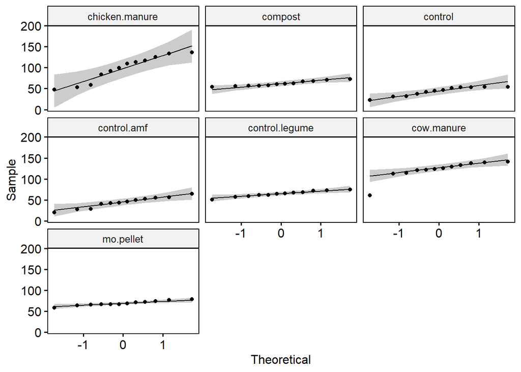

```
## Levene's Test for Homogeneity of Variance (center = median)
##       Df F value Pr(>F)
## group  6  0.7596  0.613
##       14
```

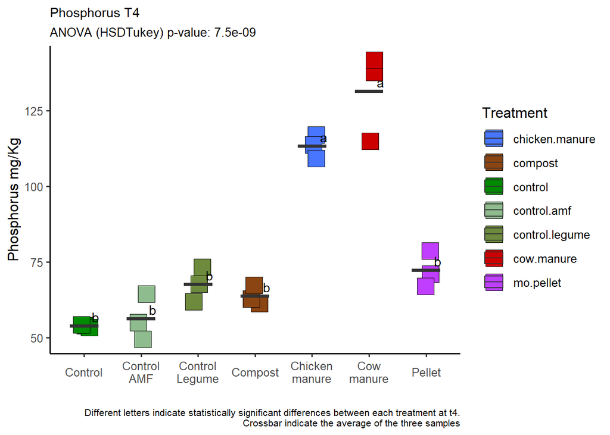

```
##
##  Shapiro-Wilk normality test
##
## data:  soilt4$ph.water
## W = 0.90025, p-value = 0.03539
```

```
## # A tibble: 7 x 4
##   treatment      variable statistic      p
##   <chr>          <chr>        <dbl>  <dbl>
## 1 chicken.manure ph.water     0.934 0.421
## 2 compost        ph.water     0.909 0.207
## 3 control        ph.water     0.903 0.174
## 4 control.amf    ph.water     0.956 0.722
## 5 control.legume ph.water     0.872 0.0691
## 6 cow.manure     ph.water     0.924 0.325
## 7 mo.pellet      ph.water     0.846 0.0326
```

```
##
##  Shapiro-Wilk normality test
##
## data:  soilt4$log_ph.water
## W = 0.89426, p-value = 0.02713
```

```
## # A tibble: 7 x 4
##   treatment      variable     statistic     p
##   <chr>          <chr>            <dbl> <dbl>
## 1 chicken.manure log_ph.water     0.966 0.647
## 2 compost        log_ph.water     0.977 0.708
## 3 control        log_ph.water     1.00  0.997
## 4 control.amf    log_ph.water     0.924 0.465
## 5 control.legume log_ph.water     0.75  0
## 6 cow.manure     log_ph.water     0.995 0.860
## 7 mo.pellet      log_ph.water     0.978 0.718
```

```
## # A tibble: 7 x 4
##   treatment      variable     statistic      p
##   <chr>          <chr>            <dbl>  <dbl>
## 1 chicken.manure log_ph.water     0.941 0.509
## 2 compost        log_ph.water     0.910 0.215
## 3 control        log_ph.water     0.898 0.151
## 4 control.amf    log_ph.water     0.954 0.699
## 5 control.legume log_ph.water     0.870 0.0654
## 6 cow.manure     log_ph.water     0.925 0.333
## 7 mo.pellet      log_ph.water     0.845 0.0323
```

```
##
##  Shapiro-Wilk normality test
##
## data:  soilt4$sqrt_ph.water
## W = 0.89729, p-value = 0.03101
```

```
## # A tibble: 7 x 4
##   treatment      variable      statistic     p
##   <chr>          <chr>             <dbl> <dbl>
## 1 chicken.manure sqrt_ph.water     0.965 0.642
## 2 compost        sqrt_ph.water     0.978 0.713
## 3 control        sqrt_ph.water     1.00  0.998
## 4 control.amf    sqrt_ph.water     0.923 0.464
## 5 control.legume sqrt_ph.water     0.75  0
## 6 cow.manure     sqrt_ph.water     0.995 0.864
## 7 mo.pellet      sqrt_ph.water     0.978 0.715
```

```
## # A tibble: 7 x 4
##   treatment      variable      statistic      p
##   <chr>          <chr>             <dbl>  <dbl>
## 1 chicken.manure sqrt_ph.water     0.937 0.465
## 2 compost        sqrt_ph.water     0.910 0.211
## 3 control        sqrt_ph.water     0.901 0.162
## 4 control.amf    sqrt_ph.water     0.955 0.711
## 5 control.legume sqrt_ph.water     0.871 0.0673
## 6 cow.manure     sqrt_ph.water     0.925 0.329
## 7 mo.pellet      sqrt_ph.water     0.846 0.0324
```

```
##
##  Shapiro-Wilk normality test
##
## data:  soilt4$inv_ph.water
## W = 0.88804, p-value = 0.02066
```

```
## # A tibble: 7 x 4
##   treatment      variable     statistic     p
##   <chr>          <chr>            <dbl> <dbl>
## 1 chicken.manure inv_ph.water     0.968 0.656
## 2 compost        inv_ph.water     0.975 0.698
## 3 control        inv_ph.water     1.00  0.994
## 4 control.amf    inv_ph.water     0.924 0.467
## 5 control.legume inv_ph.water     0.75  0
## 6 cow.manure     inv_ph.water     0.994 0.852
## 7 mo.pellet      inv_ph.water     0.979 0.723
```

```
## # A tibble: 7 x 4
##   treatment      variable     statistic      p
##   <chr>          <chr>            <dbl>  <dbl>
## 1 chicken.manure inv_ph.water     0.947 0.595
## 2 compost        inv_ph.water     0.911 0.222
## 3 control        inv_ph.water     0.893 0.130
## 4 control.amf    inv_ph.water     0.953 0.674
## 5 control.legume inv_ph.water     0.868 0.0619
## 6 cow.manure     inv_ph.water     0.926 0.339
## 7 mo.pellet      inv_ph.water     0.845 0.0319
```

```
##
##  Shapiro-Wilk normality test
##
## data:  soilt4$sum_ph.water
## W = 0.90025, p-value = 0.03539
```

```
## # A tibble: 7 x 4
##   treatment      variable     statistic     p
##   <chr>          <chr>            <dbl> <dbl>
## 1 chicken.manure sum_ph.water     0.964 0.637
## 2 compost        sum_ph.water     0.978 0.719
## 3 control        sum_ph.water     1     1.00
## 4 control.amf    sum_ph.water     0.923 0.463
## 5 control.legume sum_ph.water     0.75  0
## 6 cow.manure     sum_ph.water     0.995 0.868
## 7 mo.pellet      sum_ph.water     0.977 0.712
```

```
## # A tibble: 7 x 4
##   treatment      variable     statistic      p
##   <chr>          <chr>            <dbl>  <dbl>
## 1 chicken.manure sum_ph.water     0.934 0.421
## 2 compost        sum_ph.water     0.909 0.207
## 3 control        sum_ph.water     0.903 0.174
## 4 control.amf    sum_ph.water     0.956 0.722
## 5 control.legume sum_ph.water     0.872 0.0691
## 6 cow.manure     sum_ph.water     0.924 0.325
## 7 mo.pellet      sum_ph.water     0.846 0.0326
```

```
##
##  Shapiro-Wilk normality test
##
## data:  soilt4$mul_ph.water
## W = 0.90025, p-value = 0.03539
```

```
## # A tibble: 7 x 4
##   treatment      variable     statistic     p
##   <chr>          <chr>            <dbl> <dbl>
## 1 chicken.manure mul_ph.water     0.964 0.637
## 2 compost        mul_ph.water     0.978 0.719
## 3 control        mul_ph.water     1     1.00
## 4 control.amf    mul_ph.water     0.923 0.463
## 5 control.legume mul_ph.water     0.75  0
## 6 cow.manure     mul_ph.water     0.995 0.868
## 7 mo.pellet      mul_ph.water     0.977 0.712
```

```
## # A tibble: 7 x 4
##   treatment      variable     statistic      p
##   <chr>          <chr>            <dbl>  <dbl>
## 1 chicken.manure mul_ph.water     0.934 0.421
## 2 compost        mul_ph.water     0.909 0.207
## 3 control        mul_ph.water     0.903 0.174
## 4 control.amf    mul_ph.water     0.956 0.722
## 5 control.legume mul_ph.water     0.872 0.0691
## 6 cow.manure     mul_ph.water     0.924 0.325
## 7 mo.pellet      mul_ph.water     0.846 0.0326
```

```
##        treatment sqrt_ph.water groups
## 1    control.amf      2.929727      a
## 2      mo.pellet      2.920015      a
## 3        control      2.918896      a
## 4        compost      2.899893     ab
## 5     cow.manure      2.896496     ab
## 6 control.legume      2.895974     ab
## 7 chicken.manure      2.847119      b
```

```
##        treatment sqrt_ph.water
## 1 chicken.manure      2.847119
## 2        compost      2.899893
## 3        control      2.918896
## 4    control.amf      2.929727
## 5 control.legume      2.895974
## 6     cow.manure      2.896496
## 7      mo.pellet      2.920015
```

```
##  [1] 2.927456 2.918904 2.910326 2.927456 2.937686 2.924038 2.879236 2.840775
##  [9] 2.821347 2.874022 2.917190 2.898275 2.905168 2.937686 2.917190 2.905168
## [17] 2.927456 2.867054 2.898275 2.894823 2.894823
```

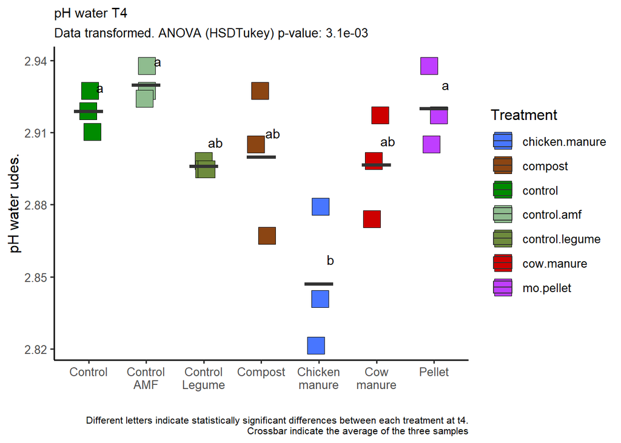

```
##
##  Shapiro-Wilk normality test
##
## data:  soilt4$calcium
## W = 0.95179, p-value = 0.368
```

```
## Levene's Test for Homogeneity of Variance (center = median)
##       Df F value Pr(>F)
## group  6    0.36 0.8922
##       14
```

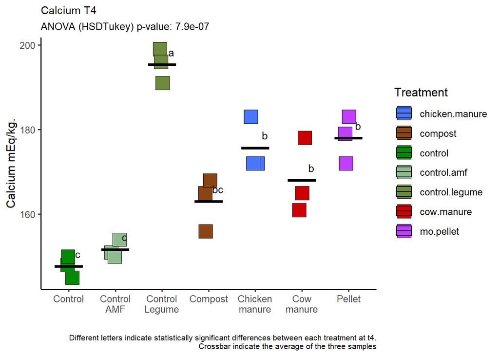

```
##
##  Shapiro-Wilk normality test
##
## data:  soilt4$sodium
## W = 0.96276, p-value = 0.5733
```

```
## Levene's Test for Homogeneity of Variance (center = median)
##       Df F value Pr(>F)
## group  6  0.4599 0.8265
##       14
```

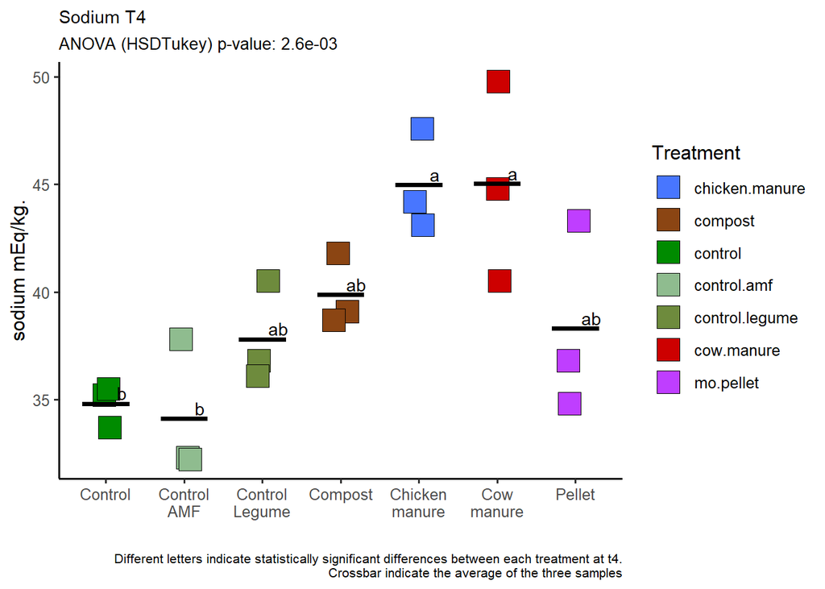

```
##
##  Shapiro-Wilk normality test
##
## data:  soilt4$potassium
## W = 0.86915, p-value = 0.009245
```

```
## # A tibble: 7 x 4
##   treatment      variable  statistic     p
##   <chr>          <chr>         <dbl> <dbl>
## 1 chicken.manure potassium     0.842 0.220
## 2 compost        potassium     0.916 0.439
## 3 control        potassium     0.949 0.567
## 4 control.amf    potassium     0.955 0.593
## 5 control.legume potassium     0.997 0.890
## 6 cow.manure     potassium     0.947 0.558
## 7 mo.pellet      potassium     0.871 0.298
```

```
## Levene's Test for Homogeneity of Variance (center = median)
##       Df F value Pr(>F)
## group  6  1.1871 0.3677
##       14
```

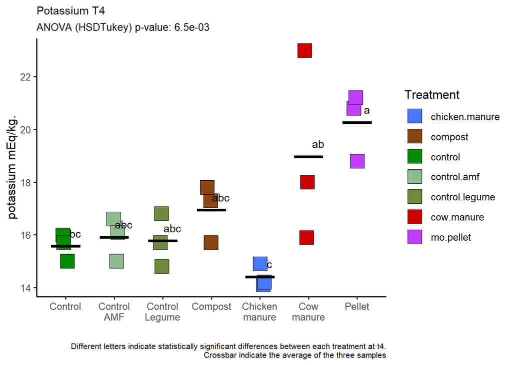

```
##
##  Shapiro-Wilk normality test
##
## data:  soilt4$nitrogen
## W = 0.92682, p-value = 0.1189
```

```
## Levene's Test for Homogeneity of Variance (center = median)
##       Df F value Pr(>F)
## group  6  0.3821 0.8784
##       14
```

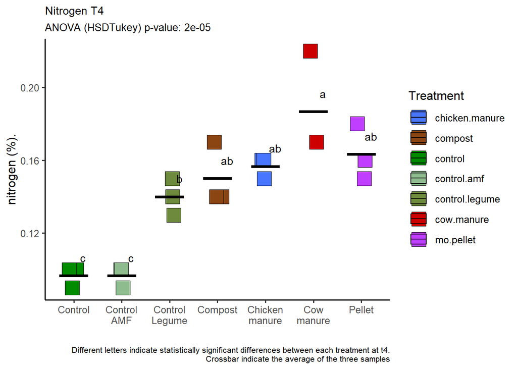

```r
ggsave(plot_orgmatter_t4, file="soil_parameters_result/orgmatter_t4.png", width= 1900,height= 1200, units= "px")
```

### PCA

```r
#PCA reducir la dimensionalidad de los datos. Componetes=dimensiones. Simplificar la complejidad en conjuntos de datos grandes.  Es una técnica de reducción de dimensionalidad que transforma los datos originales en un conjunto nuevo de variables (los componentes principales) que son no correlacionadas y que explican la mayor cantidad posible de la varianza total. Si la varianza es mayor, es el dato que mas varia.
#Hay que escalar y centrar los datos primero. (prcomp(resta la media de cada una de las varibles), scale(desviacion tipica)) para reducir la variabilidad de todas las muestras
#PAra elegir las componentes, ver en plot(data, type"l")lo que forme un codo. Summary(dta)Elegir por ejemplo hasta explicar 80% en cumalative proportion. *Explicar con la variacion de los datos que tengo*

soil_prop_pca <- data.frame(soil_prop)
soil_prop_pca$soil.id<- NULL
soil_prop_pca$rep<-NULL
soil_prop_pca
```

```
##         treatment time org.matter phosphorus calcium magnesium sodium potassium
## 1         control   t0     2.4841       31.5     140      60.9   20.9      13.4
## 2         control   t0     2.4511       32.1     135      53.5   18.3      11.5
## 3         control   t0     2.3200       22.7     135      55.1   17.4       9.0
## 4     control.amf   t0     2.3590       28.9     131      53.5   17.0       9.0
## 5     control.amf   t0     2.4270       27.5     148      58.4   18.7      10.9
## 6     control.amf   t0     2.3410       20.2     130      54.3   17.4       7.7
## 7  chicken.manure   t0     3.6100       53.1     191      58.4   18.1      19.2
## 8  chicken.manure   t0     3.7190       47.9     213      63.4   19.1      24.3
## 9  chicken.manure   t0     3.3670       58.6     182      56.8   17.0      20.5
## 10     cow.manure   t0     3.9240       60.8     168      74.9   19.8      26.2
## 11     cow.manure   t0     4.0890      120.8     170      74.1   20.2      25.6
## 12     cow.manure   t0     4.1720      124.0     168      68.3   18.3      21.7
## 13      mo.pellet   t0     2.5540       68.5     119      56.0   18.5      12.8
## 14      mo.pellet   t0     2.7580       66.3     144      52.7   21.5      18.5
```

[output cut: 325 more lines]

```r
info_soil <- soil_prop_pca[, c(1:2)]

numeric_col_soil<-  sapply(soil_prop_pca, is.numeric)#hay que separar los numeros del texto. solo pueden tener valores numericos
pca_soil_data <- scale(soil_prop_pca[, numeric_col_soil]) #nos lo ha escalado (ajustado la desviacion tipica)

pca_soil_result <- prcomp(pca_soil_data, center = TRUE, scale. = TRUE) #escalado y centrado de los datos
summary(pca_soil_result)
```

```
## Importance of components:
##                           PC1    PC2    PC3     PC4     PC5    PC6     PC7
## Standard deviation     3.0609 1.8336 1.4204 1.04588 0.90777 0.7061 0.55899
## Proportion of Variance 0.5205 0.1868 0.1121 0.06077 0.04578 0.0277 0.01736
## Cumulative Proportion  0.5205 0.7073 0.8194 0.88015 0.92593 0.9536 0.97099
##                            PC8     PC9    PC10    PC11    PC12    PC13    PC14
## Standard deviation     0.45576 0.41466 0.32247 0.16537 0.10083 0.03009 0.01289
## Proportion of Variance 0.01154 0.00955 0.00578 0.00152 0.00056 0.00005 0.00001
## Cumulative Proportion  0.98253 0.99208 0.99786 0.99938 0.99994 0.99999 1.00000
##                             PC15      PC16      PC17      PC18
## Standard deviation     0.0003773 1.768e-06 9.474e-16 4.433e-16
## Proportion of Variance 0.0000000 0.000e+00 0.000e+00 0.000e+00
## Cumulative Proportion  1.0000000 1.000e+00 1.000e+00 1.000e+00
```

```r
pca_soil_result
```

```
## Standard deviations (1, .., p=18):
##  [1] 3.060877e+00 1.833648e+00 1.420396e+00 1.045884e+00 9.077698e-01
##  [6] 7.061302e-01 5.589896e-01 4.557626e-01 4.146629e-01 3.224685e-01
## [11] 1.653650e-01 1.008344e-01 3.008901e-02 1.288556e-02 3.773326e-04
## [16] 1.767796e-06 9.473901e-16 4.432650e-16
##
## Rotation (n x k) = (18 x 18):
##                           PC1         PC2         PC3          PC4          PC5
## org.matter         0.15009256  0.32313165 -0.08432237 -0.380600372 -0.378018602
## phosphorus         0.09880368  0.32506766  0.21259761 -0.151221777  0.628683303
## calcium            0.08471903  0.14910080  0.56751295 -0.101518039 -0.200694745
## magnesium         -0.05702250  0.38440157 -0.28690949  0.256129878  0.215521741
## sodium            -0.08567742  0.37171208 -0.15674310  0.431842954  0.242964077
## potassium          0.03322305  0.03010770  0.61651560 -0.066352266  0.293140320
## ph.water          -0.31575979  0.11204112  0.06164301  0.008671333 -0.082483662
## pH.chloride       -0.19542722  0.34972209  0.14567250  0.070780368 -0.257495087
## conductivity       0.27898109  0.07537636  0.12811269  0.384109420 -0.158214673
## nitrogen           0.20417186  0.34179571 -0.15869854 -0.324534223 -0.006081709
## sqrt_conductivity  0.27953116  0.12390839  0.12187958  0.345018912 -0.197364081
## log_nitrogen       0.20622997  0.34026407 -0.16637413 -0.315169828 -0.026861596
## log_ph.water      -0.31588545  0.11302832  0.05674176 -0.002471381 -0.082064148
## sqrt_ph.water     -0.31585392  0.11254991  0.05921267  0.003131445 -0.082306754
## inv_ph.water       0.31575483 -0.11389114 -0.05169197  0.013843901  0.081372600
## sum_ph.water      -0.31575979  0.11204112  0.06164301  0.008671333 -0.082483662
## mul_ph.water      -0.31575979  0.11204112  0.06164301  0.008671333 -0.082483662
## log_conductivity   0.26851213  0.16978489  0.11177275  0.297993895 -0.242034387
##                           PC6         PC7         PC8         PC9        PC10
## org.matter        -0.41982219 -0.05898949  0.44192432 -0.16383413  0.33001506
## phosphorus         0.34743542  0.19690458  0.12413393 -0.41328780  0.24017389
## calcium           -0.34712337  0.42328349 -0.36016470 -0.24843686 -0.30706254
## magnesium         -0.39413543 -0.45631208 -0.41348868 -0.32485410  0.01933737
## sodium            -0.30604681  0.47104449  0.30893894  0.39515936 -0.12905094
## potassium         -0.22581449 -0.51081053  0.16732023  0.42635013  0.01379319
## ph.water           0.09082293 -0.07091527  0.08643844 -0.07316484 -0.13554127
## pH.chloride        0.22865560  0.09779616 -0.42855750  0.35975294  0.60880180
## conductivity       0.16171390 -0.14455970 -0.06036320 -0.04438028 -0.19297887
## nitrogen           0.18260163 -0.11140174 -0.09832589  0.25278801 -0.34368295
## sqrt_conductivity  0.18274439 -0.10770764  0.10609657 -0.07772430 -0.04409519
## log_nitrogen       0.21665840 -0.01787329 -0.09575232  0.19648346 -0.30258663
## log_ph.water       0.09006753 -0.06093943  0.10748629 -0.07574843 -0.11913136
```

[output cut: 28 more lines]

```
## magnesium         -1.114109e-04 -5.632823e-07 -1.972276e-16  1.033658e-16
## sodium             1.467942e-04 -4.268419e-07 -3.342034e-17 -7.638586e-17
## potassium         -7.248965e-05 -2.014544e-07 -1.350084e-16 -1.114211e-16
## ph.water           2.253551e-01 -9.887868e-02  2.587387e-01 -7.744165e-01
## pH.chloride        1.887876e-04 -3.887544e-07  4.147042e-16  1.443066e-16
## conductivity       1.053395e-02 -5.035512e-06 -3.455790e-16 -3.247348e-15
## nitrogen           4.020458e-04  1.802405e-06 -1.683757e-16  1.400495e-16
## sqrt_conductivity -1.899252e-02  1.240602e-05  2.210748e-15  5.495332e-15
## log_nitrogen      -3.612354e-04 -1.300868e-06 -5.094501e-16 -6.352178e-17
## log_ph.water      -6.598270e-01 -5.860329e-01 -1.473387e-10 -2.927615e-11
## sqrt_ph.water     -4.616440e-01  7.860676e-01  1.979833e-10  3.944639e-11
## inv_ph.water      -4.456566e-01 -9.660329e-02 -2.420175e-11 -4.781017e-12
## sum_ph.water       2.253551e-01 -9.887868e-02  5.412950e-01  6.112826e-01
## mul_ph.water       2.253551e-01 -9.887868e-02 -8.000337e-01  1.631340e-01
## log_conductivity   8.746286e-03 -6.617159e-06 -1.798766e-15 -2.419319e-15
```

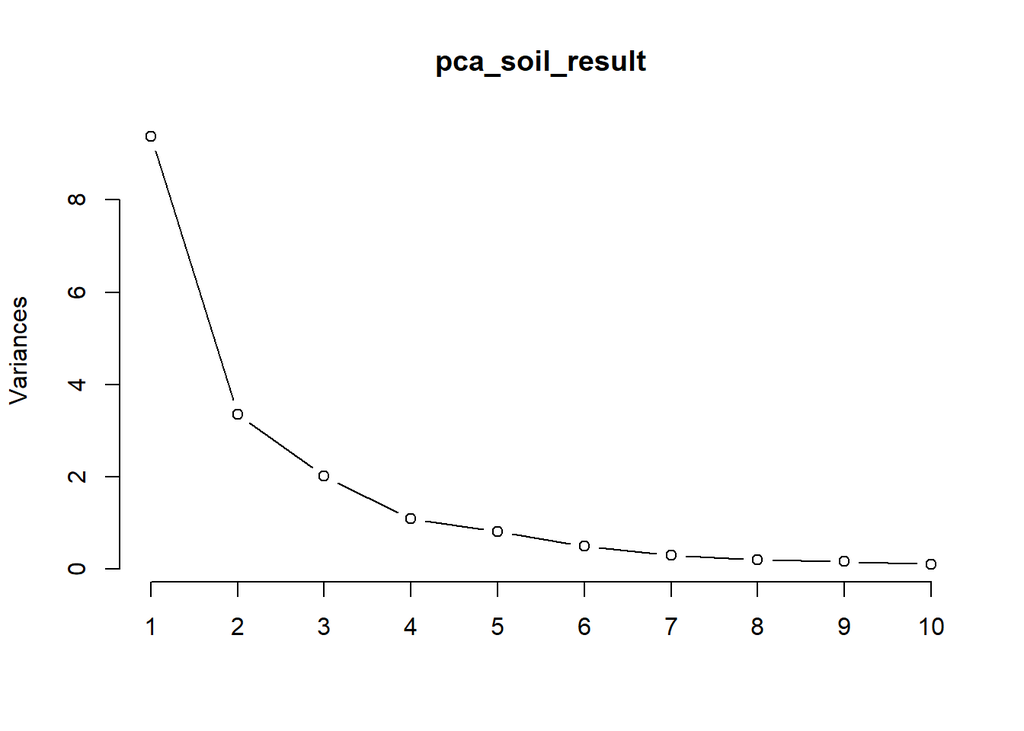

```r
# Visualización de la proporción de varianza explicada
plot(pca_soil_result, type = "l")
```

```r
pca_scores <- pca_soil_result$x %>% data.frame()#guardamos resultados de cada caponente en nuevo dataframe
pca_soil <- data.frame(pca_scores,info_soil)# y unimos con la informacion de cada valor


valores_acumulativos <- summary(pca_soil_result)$importance
valor_PC1<- valores_acumulativos[3, 1]
valor_PC1
```

```
## [1] 0.5205
```

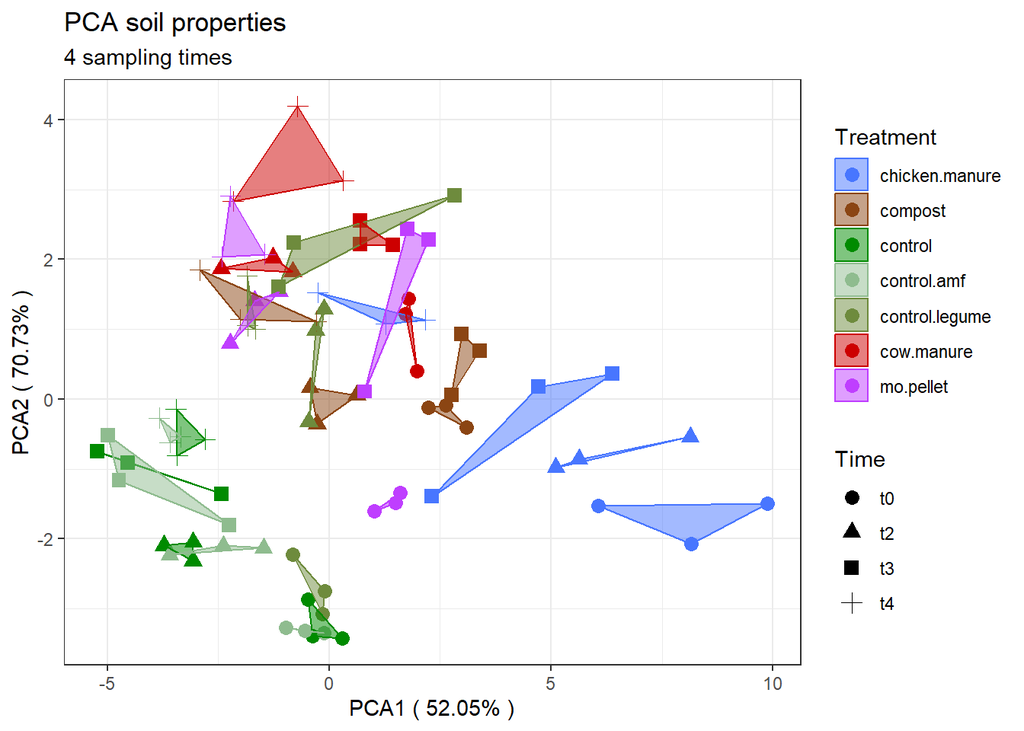

```r
valor_PC2<-valores_acumulativos[3, 2]

plot_pca <- pca_soil  %>% ggplot(aes(PC1, PC2, colour= treatment, shape= time))+
  geom_point(size=3)+
  xlab(paste("PCA1 (", sprintf("%.2f%%", valor_PC1 * 100), ")")) +  # para add % acumulativo
  ylab(paste("PCA2 (", sprintf("%.2f%%", valor_PC2 * 100), ")"))+
  labs(title = "PCA soil properties", subtitle= "4 sampling times")+
  scale_fill_manual(values=treat.colors)+
  scale_color_manual(values=treat.colors)+
  geom_polygon(aes(fill =  treatment, group = interaction(time, treatment)),alpha= 0.5)+
  guides(guides(
    color = guide_legend(title = "Treatment"),
    shape = guide_legend(title = "Time"),
    fill = guide_legend(title = "Treatment")
  ))+
  theme_bw()
plot_pca
```

```r
ggsave(plot_pca, file="soil_parameters_result/plot_pca_soil.png", width= 1900,height= 1200, units= "px")


#stat_ellipse(aes(group= interaction(treatment,time), col= treatment))+
  #stat_ellipse(aes(group = treatment, fill = treatment), geom = "polygon", alpha = 0.2, linetype = 2)+
#stat_ellipse(aes(group= interaction(treatment,time), col= treatment))
 #geom_polygon(aes(group= interaction(treatment, time), fill= treatment, alpha= time))

###pca de t0 y t4 ###
soil_prop_pca_t0t4 <- soil_prop_pca %>% filter(time == "t0" | time == "t4")
info_soilt0t4 <- soil_prop_pca_t0t4[, c(1:2)]

numeric_col_soilt0t4<-  sapply(soil_prop_pca_t0t4, is.numeric)#hay que separar los numeros del texto. solo pueden tener valores numericos
pca_soil_datat0t4 <- scale(soil_prop_pca_t0t4[, numeric_col_soilt0t4])

pca_soil_t0t4 <- prcomp(pca_soil_datat0t4, center = TRUE, scale. = TRUE)
summary(pca_soil_t0t4)
```

```
## Importance of components:
##                           PC1    PC2     PC3     PC4     PC5     PC6     PC7
## Standard deviation     3.1410 2.2240 1.16669 0.81414 0.73385 0.44362 0.42337
## Proportion of Variance 0.5481 0.2748 0.07562 0.03682 0.02992 0.01093 0.00996
## Cumulative Proportion  0.5481 0.8229 0.89854 0.93536 0.96528 0.97621 0.98617
##                            PC8     PC9   PC10    PC11    PC12    PC13     PC14
## Standard deviation     0.33751 0.26890 0.2123 0.11605 0.06343 0.01099 0.006444
## Proportion of Variance 0.00633 0.00402 0.0025 0.00075 0.00022 0.00001 0.000000
## Cumulative Proportion  0.99250 0.99651 0.9990 0.99977 0.99999 1.00000 1.000000
##                             PC15      PC16      PC17      PC18
## Standard deviation     0.0001021 1.026e-06 8.969e-16 2.869e-16
## Proportion of Variance 0.0000000 0.000e+00 0.000e+00 0.000e+00
## Cumulative Proportion  1.0000000 1.000e+00 1.000e+00 1.000e+00
```

```r
pca_soil_t0t4
```

```
## Standard deviations (1, .., p=18):
##  [1] 3.141045e+00 2.224030e+00 1.166692e+00 8.141434e-01 7.338481e-01
##  [6] 4.436248e-01 4.233686e-01 3.375102e-01 2.688979e-01 2.123170e-01
## [11] 1.160497e-01 6.342526e-02 1.098626e-02 6.444249e-03 1.020804e-04
## [16] 1.025761e-06 8.968901e-16 2.868843e-16
##
## Rotation (n x k) = (18 x 18):
##                            PC1         PC2           PC3          PC4
## org.matter         0.143895585  0.25298927 -0.5062358443 -0.264222379
## phosphorus         0.009458174  0.34173754 -0.1263711940  0.722591953
## calcium            0.128112307  0.32239817  0.1828193582 -0.394661796
## magnesium         -0.150709611  0.34700729  0.0799481502 -0.350035363
## sodium            -0.155469360  0.29768264  0.3063170134  0.200857595
## potassium          0.109552318  0.32516771  0.1083384882 -0.226046709
## ph.water          -0.309067886  0.10011389  0.0092678902 -0.012290700
## pH.chloride       -0.200374951  0.31135916  0.1438482887  0.023184104
## conductivity       0.275109507  0.10456990  0.3530583135 -0.002025474
## nitrogen           0.183965396  0.30375430 -0.3638732118  0.057514571
## sqrt_conductivity  0.273611042  0.14037549  0.3207135437  0.078059356
## log_nitrogen       0.185393450  0.30322713 -0.3522920446  0.074440776
## log_ph.water      -0.309962198  0.09622740 -0.0077004307  0.003893069
## sqrt_ph.water     -0.309555448  0.09819361  0.0008237432 -0.004218923
## inv_ph.water       0.310523308 -0.09216707  0.0249387250 -0.020190418
## sum_ph.water      -0.309067886  0.10011389  0.0092678902 -0.012290700
## mul_ph.water      -0.309067886  0.10011389  0.0092678902 -0.012290700
## log_conductivity   0.264762008  0.17676360  0.2769854699  0.148141190
##                            PC5         PC6          PC7          PC8
## org.matter        -0.153190029  0.18211610  0.497792510 -0.270754905
## phosphorus        -0.057821732 -0.46752962 -0.084680449 -0.038127840
## calcium           -0.434897989 -0.17778969 -0.513289902 -0.375900484
## magnesium         -0.136714602 -0.34300775  0.103441943  0.660073161
## sodium            -0.435422295  0.05371635  0.489399573 -0.194472547
## potassium          0.695744296 -0.37689391  0.226498284 -0.252230950
## ph.water           0.048603629  0.12247239 -0.003108512  0.042310089
## pH.chloride        0.251747248  0.28452182 -0.311874547 -0.202088665
## conductivity       0.013387903  0.16802491  0.090662746  0.307092768
## nitrogen           0.048257737  0.16491689 -0.181120756  0.240477805
## sqrt_conductivity  0.053593146  0.24794784  0.068908183  0.126203693
## log_nitrogen       0.008484659  0.25907368 -0.187110505  0.167364494
## log_ph.water       0.047917278  0.11707608 -0.009816842  0.003803268
```

[output cut: 47 more lines]

```
## magnesium         -9.515317e-16 -1.184702e-16
## sodium             7.136022e-16  3.660991e-16
## potassium          5.887880e-16 -3.506174e-16
## ph.water           2.908005e-01  7.629559e-01
## pH.chloride       -2.012318e-17  2.468184e-16
## conductivity       1.937894e-14  2.029711e-14
## nitrogen          -1.032442e-15  9.998476e-16
## sqrt_conductivity -3.235320e-14 -2.912486e-14
## log_nitrogen       7.054555e-16 -6.623623e-16
## log_ph.water      -2.315647e-10 -5.340726e-12
## sqrt_ph.water      3.093684e-10  6.094856e-12
## inv_ph.water      -3.850824e-11 -1.166526e-12
## sum_ph.water       5.153389e-01 -6.333186e-01
## mul_ph.water      -8.061395e-01 -1.296373e-01
## log_conductivity   1.363444e-14  1.093393e-14
```

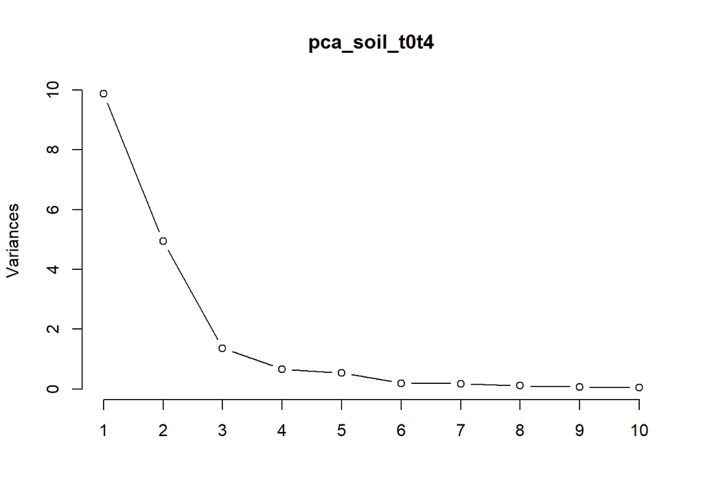

```r
plot(pca_soil_t0t4, type = "l")
```

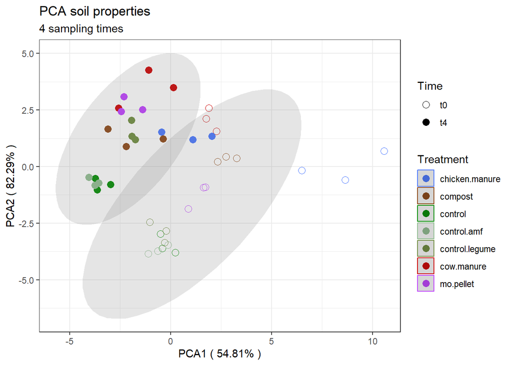

```r
pca_scorest0t4 <- pca_soil_t0t4$x %>% data.frame()
pca_soilt0t4 <- data.frame(pca_scorest0t4,info_soilt0t4)# y unimos con la informacion de cada valor

valores_acumulativost0t4 <- summary(pca_soil_t0t4)$importance
valor_PC1t0t4<- valores_acumulativost0t4[3, 1]
valor_PC2t0t4<-valores_acumulativost0t4[3, 2]

plot_pcat0t4 <- pca_soilt0t4  %>% ggplot(aes(PC1, PC2, colour= treatment, shape= time))+
  geom_point(size=3)+
  xlab(paste("PCA1 (", sprintf("%.2f%%", valor_PC1t0t4 * 100), ")")) +
  ylab(paste("PCA2 (", sprintf("%.2f%%", valor_PC2t0t4 * 100), ")"))+
  labs(title = "PCA soil properties", subtitle= "4 sampling times")+
  scale_fill_manual(values=treat.colors)+
  scale_color_manual(values=treat.colors)+
  #geom_polygon(aes(fill =  time, group = interaction(time, treatment)),alpha= 0.5)+
  guides(guides(
    color = guide_legend(title = "Treatment"),
    shape = guide_legend(title = "Time"),
    fill = guide_legend(title = "Time")
  ))+
  scale_shape_manual(values=c(1,16))+
   theme_bw()+
  stat_ellipse(aes(group =time, fill= time), level = 0.95, geom = "polygon", alpha = 0.2)
plot_pcat0t4
```

```r
ggsave(plot_pcat0t4, file="soil_parameters_result/pca_t0t4.png", width= 1900,height= 1200, units= "px")
```